# Activity Monitoring - Project 1

# Activity Monitoring: Daily Patterns and Missing-Value Imputation

*Reproducible Research course project*

```r
knitr::opts_chunk$set(echo = TRUE, fig.width = 8, fig.height = 5)
```

## Loading and preprocessing the data

The analysis starts from the supplied `activity.csv`. Dates are converted to R’s Date class.

```r
activity <- read.csv("data/activity.csv", stringsAsFactors = FALSE)
activity$date <- as.Date(activity$date)
```

## What is the mean total number of steps taken per day?

Missing observations are ignored for this first calculation. Days containing only missing observations are therefore excluded from the summary.

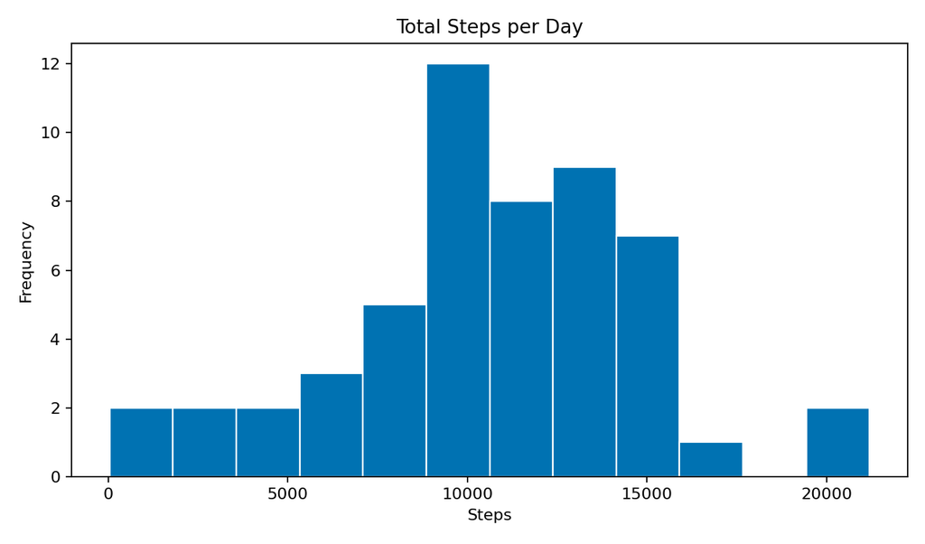

Output for daily-total

```r
daily <- aggregate(steps ~ date, activity, sum, na.rm = TRUE)
hist(daily$steps, breaks = 12, col = "#0072B2",
     main = "Total Steps per Day", xlab = "Steps")
mean(daily$steps)
median(daily$steps)
```

The mean daily total is approximately **10,766.19 steps** and the median is **10,765 steps**.

## What is the average daily activity pattern?

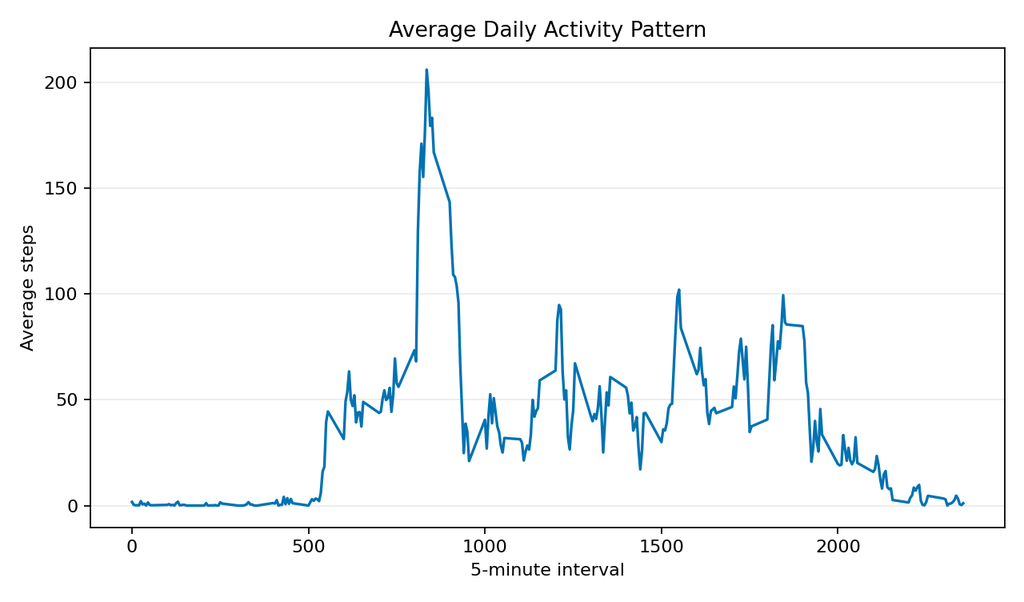

Output for pattern

```r
pattern <- aggregate(steps ~ interval, activity, mean, na.rm = TRUE)
plot(pattern$interval, pattern$steps, type = "l", col = "#0072B2", lwd = 2,
     main = "Average Daily Activity Pattern", xlab = "5-minute interval",
     ylab = "Average steps")
pattern$interval[which.max(pattern$steps)]
max(pattern$steps)
```

Interval **835** has the largest average, approximately **206.17 steps**.

## Imputing missing values

There are **2,304** missing step observations. Each missing value is replaced with the mean for its 5-minute interval across all observed days. This retains the daily time profile while avoiding an arbitrary zero replacement.

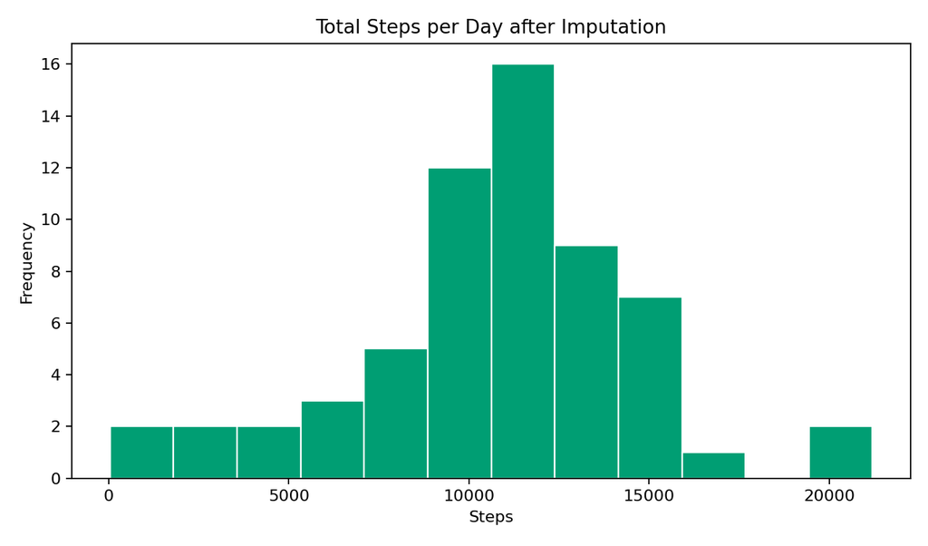

Output for impute

```r
sum(is.na(activity$steps))
interval.means <- tapply(activity$steps, activity$interval, mean, na.rm = TRUE)
activity.imputed <- activity
missing <- is.na(activity.imputed$steps)
activity.imputed$steps[missing] <- interval.means[as.character(activity.imputed$interval[missing])]
daily.imputed <- aggregate(steps ~ date, activity.imputed, sum)
hist(daily.imputed$steps, breaks = 12, col = "#009E73",
     main = "Total Steps per Day after Imputation", xlab = "Steps")
mean(daily.imputed$steps)
median(daily.imputed$steps)
```

After imputation, the mean is approximately **10,766.19** and the median is **10,766.19** steps. The mean is unchanged because interval means were used. The median moves slightly and formerly missing days are restored to the distribution.

## Are there differences between weekdays and weekends?

[figure not shown]

Output for weekday-weekend

```r
activity.imputed$day.type <- factor(ifelse(weekdays(activity.imputed$date) %in% c("Saturday", "Sunday"), "weekend", "weekday"), levels = c("weekday", "weekend"))
patterns <- aggregate(steps ~ interval + day.type, activity.imputed, mean)
par(mfrow = c(2, 1), mar = c(4, 4, 3, 1))
for (d in levels(patterns$day.type)) {
  x <- subset(patterns, day.type == d)
  plot(x$interval, x$steps, type = "l", lwd = 2,
       col = ifelse(d == "weekday", "#0072B2", "#D55E00"),
       main = paste("Average activity:", d), xlab = "5-minute interval",
       ylab = "Average steps")
}
par(mfrow = c(1, 1))
```

[output not shown]